# Presentación interactiva "Exploración y Modelamiento de Datos"

## Carga del dataset

```python
file_name = "movie_metadata.csv"
dataset = pd.read_csv(file_name)
```

## Descripción del Dataset

Cantidad de registros y número de columnas

```python
dataset.shape
```

```
(5043, 28)
```

Inferencia del dataset

```python
print("\033[1mInference:\033[0m El dataset consiste de {} features y {} ejemplos".format(dataset.shape[1], dataset.shape[0]))
```

```
Inference: El dataset consiste de 28 features y 5043 ejemplos
```

Columnas del dataset

```python
dataset.keys()
```

```
Index(['color', 'director_name', 'num_critic_for_reviews', 'duration',
       'director_facebook_likes', 'actor_3_facebook_likes', 'actor_2_name',
       'actor_1_facebook_likes', 'gross', 'genres', 'actor_1_name',
       'movie_title', 'num_voted_users', 'cast_total_facebook_likes',
       'actor_3_name', 'facenumber_in_poster', 'plot_keywords',
       'movie_imdb_link', 'num_user_for_reviews', 'language', 'country',
       'content_rating', 'budget', 'title_year', 'actor_2_facebook_likes',
       'imdb_score', 'aspect_ratio', 'movie_facebook_likes'],
      dtype='object')
```

Ejemplos de los primeros 5 y últimos 5 registros del dataset

```python
dataset.head()
```

|  | color | director_name | num_critic_for_reviews | duration | director_facebook_likes | actor_3_facebook_likes | actor_2_name | actor_1_facebook_likes | gross | genres | ... | num_user_for_reviews | language | country | content_rating | budget | title_year | actor_2_facebook_likes | imdb_score | aspect_ratio | movie_facebook_likes |
| --- | --- | --- | --- | --- | --- | --- | --- | --- | --- | --- | --- | --- | --- | --- | --- | --- | --- | --- | --- | --- | --- |
| 0 | Color | James Cameron | 723.0 | 178.0 | 0.0 | 855.0 | Joel David Moore | 1000.0 | 760505847.0 | Action\|Adventure\|Fantasy\|Sci-Fi | ... | 3054.0 | English | USA | PG-13 | 237000000.0 | 2009.0 | 936.0 | 7.9 | 1.78 | 33000 |
| 1 | Color | Gore Verbinski | 302.0 | 169.0 | 563.0 | 1000.0 | Orlando Bloom | 40000.0 | 309404152.0 | Action\|Adventure\|Fantasy | ... | 1238.0 | English | USA | PG-13 | 300000000.0 | 2007.0 | 5000.0 | 7.1 | 2.35 | 0 |
| 2 | Color | Sam Mendes | 602.0 | 148.0 | 0.0 | 161.0 | Rory Kinnear | 11000.0 | 200074175.0 | Action\|Adventure\|Thriller | ... | 994.0 | English | UK | PG-13 | 245000000.0 | 2015.0 | 393.0 | 6.8 | 2.35 | 85000 |
| 3 | Color | Christopher Nolan | 813.0 | 164.0 | 22000.0 | 23000.0 | Christian Bale | 27000.0 | 448130642.0 | Action\|Thriller | ... | 2701.0 | English | USA | PG-13 | 250000000.0 | 2012.0 | 23000.0 | 8.5 | 2.35 | 164000 |
| 4 | NaN | Doug Walker | NaN | NaN | 131.0 | NaN | Rob Walker | 131.0 | NaN | Documentary | ... | NaN | NaN | NaN | NaN | NaN | NaN | 12.0 | 7.1 | NaN | 0 |

5 rows × 28 columns

```python
dataset.tail()
```

|  | color | director_name | num_critic_for_reviews | duration | director_facebook_likes | actor_3_facebook_likes | actor_2_name | actor_1_facebook_likes | gross | genres | ... | num_user_for_reviews | language | country | content_rating | budget | title_year | actor_2_facebook_likes | imdb_score | aspect_ratio | movie_facebook_likes |
| --- | --- | --- | --- | --- | --- | --- | --- | --- | --- | --- | --- | --- | --- | --- | --- | --- | --- | --- | --- | --- | --- |
| 5038 | Color | Scott Smith | 1.0 | 87.0 | 2.0 | 318.0 | Daphne Zuniga | 637.0 | NaN | Comedy\|Drama | ... | 6.0 | English | Canada | NaN | NaN | 2013.0 | 470.0 | 7.7 | NaN | 84 |
| 5039 | Color | NaN | 43.0 | 43.0 | NaN | 319.0 | Valorie Curry | 841.0 | NaN | Crime\|Drama\|Mystery\|Thriller | ... | 359.0 | English | USA | TV-14 | NaN | NaN | 593.0 | 7.5 | 16.00 | 32000 |
| 5040 | Color | Benjamin Roberds | 13.0 | 76.0 | 0.0 | 0.0 | Maxwell Moody | 0.0 | NaN | Drama\|Horror\|Thriller | ... | 3.0 | English | USA | NaN | 1400.0 | 2013.0 | 0.0 | 6.3 | NaN | 16 |
| 5041 | Color | Daniel Hsia | 14.0 | 100.0 | 0.0 | 489.0 | Daniel Henney | 946.0 | 10443.0 | Comedy\|Drama\|Romance | ... | 9.0 | English | USA | PG-13 | NaN | 2012.0 | 719.0 | 6.3 | 2.35 | 660 |
| 5042 | Color | Jon Gunn | 43.0 | 90.0 | 16.0 | 16.0 | Brian Herzlinger | 86.0 | 85222.0 | Documentary | ... | 84.0 | English | USA | PG | 1100.0 | 2004.0 | 23.0 | 6.6 | 1.85 | 456 |

5 rows × 28 columns

Validar el número de filas únicas en cada feature

```python
dataset.nunique().sort_values()
```

```
color                           2
content_rating                 18
facenumber_in_poster           19
aspect_ratio                   22
language                       46
country                        65
imdb_score                     78
title_year                     91
duration                      191
director_facebook_likes       435
budget                        439
num_critic_for_reviews        528
movie_facebook_likes          876
actor_1_facebook_likes        878
actor_3_facebook_likes        906
genres                        914
actor_2_facebook_likes        917
num_user_for_reviews          954
actor_1_name                 2097
director_name                2398
actor_2_name                 3032
actor_3_name                 3521
cast_total_facebook_likes    3978
gross                        4035
plot_keywords                4760
num_voted_users              4826
movie_title                  4917
movie_imdb_link              4919
dtype: int64
```

Listado de valores únicos por columna

```python
for key in dataset.keys():
    unique = dataset[key].unique()
    print(f"\033[1m{key}:\033[0m")
    print(f"\t- Total de datos únicos: {len(unique)}")
    print(f"\t- Valores: {unique}\n")
```

[output not shown]

[output cut: 1357 more lines]

[output not shown]

## Análisis general del dataset

Descripción de información estadística básica y general del dataset

```python
dataset.describe()
```

|  | num_critic_for_reviews | duration | director_facebook_likes | actor_3_facebook_likes | actor_1_facebook_likes | gross | num_voted_users | cast_total_facebook_likes | facenumber_in_poster | num_user_for_reviews | budget | title_year | actor_2_facebook_likes | imdb_score | aspect_ratio | movie_facebook_likes |
| --- | --- | --- | --- | --- | --- | --- | --- | --- | --- | --- | --- | --- | --- | --- | --- | --- |
| count | 4993.000000 | 5028.000000 | 4939.000000 | 5020.000000 | 5036.000000 | 4.159000e+03 | 5.043000e+03 | 5043.000000 | 5030.000000 | 5022.000000 | 4.551000e+03 | 4935.000000 | 5030.000000 | 5043.000000 | 4714.000000 | 5043.000000 |
| mean | 140.194272 | 107.201074 | 686.509212 | 645.009761 | 6560.047061 | 4.846841e+07 | 8.366816e+04 | 9699.063851 | 1.371173 | 272.770808 | 3.975262e+07 | 2002.470517 | 1651.754473 | 6.442138 | 2.220403 | 7525.964505 |
| std | 121.601675 | 25.197441 | 2813.328607 | 1665.041728 | 15020.759120 | 6.845299e+07 | 1.384853e+05 | 18163.799124 | 2.013576 | 377.982886 | 2.061149e+08 | 12.474599 | 4042.438863 | 1.125116 | 1.385113 | 19320.445110 |
| min | 1.000000 | 7.000000 | 0.000000 | 0.000000 | 0.000000 | 1.620000e+02 | 5.000000e+00 | 0.000000 | 0.000000 | 1.000000 | 2.180000e+02 | 1916.000000 | 0.000000 | 1.600000 | 1.180000 | 0.000000 |
| 25% | 50.000000 | 93.000000 | 7.000000 | 133.000000 | 614.000000 | 5.340988e+06 | 8.593500e+03 | 1411.000000 | 0.000000 | 65.000000 | 6.000000e+06 | 1999.000000 | 281.000000 | 5.800000 | 1.850000 | 0.000000 |
| 50% | 110.000000 | 103.000000 | 49.000000 | 371.500000 | 988.000000 | 2.551750e+07 | 3.435900e+04 | 3090.000000 | 1.000000 | 156.000000 | 2.000000e+07 | 2005.000000 | 595.000000 | 6.600000 | 2.350000 | 166.000000 |
| 75% | 195.000000 | 118.000000 | 194.500000 | 636.000000 | 11000.000000 | 6.230944e+07 | 9.630900e+04 | 13756.500000 | 2.000000 | 326.000000 | 4.500000e+07 | 2011.000000 | 918.000000 | 7.200000 | 2.350000 | 3000.000000 |
| max | 813.000000 | 511.000000 | 23000.000000 | 23000.000000 | 640000.000000 | 7.605058e+08 | 1.689764e+06 | 656730.000000 | 43.000000 | 5060.000000 | 1.221550e+10 | 2016.000000 | 137000.000000 | 9.500000 | 16.000000 | 349000.000000 |

Descripción de tipos y cantidades de datos non-nulls en el dataset

```python
dataset.info()
```

```
<class 'pandas.core.frame.DataFrame'>
RangeIndex: 5043 entries, 0 to 5042
Data columns (total 28 columns):
 #   Column                     Non-Null Count  Dtype
---  ------                     --------------  -----
 0   color                      5024 non-null   object
 1   director_name              4939 non-null   object
 2   num_critic_for_reviews     4993 non-null   float64
 3   duration                   5028 non-null   float64
 4   director_facebook_likes    4939 non-null   float64
 5   actor_3_facebook_likes     5020 non-null   float64
 6   actor_2_name               5030 non-null   object
 7   actor_1_facebook_likes     5036 non-null   float64
 8   gross                      4159 non-null   float64
 9   genres                     5043 non-null   object
```

[output cut: 20 more lines]

## Limpieza de columnas irrelevantes o "sucias"

Las siguientes variables serán eliminadas del dataset, dado que están generando ruido en el modelo, y no están aportando un valor real en el valor predictivo:

| Variable | Motivo |
| --- | --- |
| `movie_imdb_link` | Es un identificador externo (URL) |
| `movie_title` | Es un indicador nominal que no aporta valor predictivo |
| `director_name` | Es un indicador nominal que no aporta valor predictivo |
| `actor_1_name` | Es un indicador nominal que no aporta valor predictivo |
| `actor_2_name` | Es un indicador nominal que no aporta valor predictivo |
| `actor_3_name` | Es un indicador nominal que no aporta valor predictivo |
| `plot_keywords` | Texto libre que sería útil usando NLP |

```python
cols_to_drop = [
    'movie_imdb_link', 'movie_title', 'director_name',
    'actor_1_name', 'actor_2_name', 'actor_3_name',
    'plot_keywords',
]

dataset = dataset.drop(columns=cols_to_drop)
```

```python
dataset.info()
```

```
<class 'pandas.core.frame.DataFrame'>
RangeIndex: 5043 entries, 0 to 5042
Data columns (total 21 columns):
 #   Column                     Non-Null Count  Dtype
---  ------                     --------------  -----
 0   color                      5024 non-null   object
 1   num_critic_for_reviews     4993 non-null   float64
 2   duration                   5028 non-null   float64
 3   director_facebook_likes    4939 non-null   float64
 4   actor_3_facebook_likes     5020 non-null   float64
 5   actor_1_facebook_likes     5036 non-null   float64
 6   gross                      4159 non-null   float64
 7   genres                     5043 non-null   object
 8   num_voted_users            5043 non-null   int64
 9   cast_total_facebook_likes  5043 non-null   int64
 10  facenumber_in_poster       5030 non-null   float64
 11  num_user_for_reviews       5022 non-null   float64
 12  language                   5029 non-null   object
 13  country                    5038 non-null   object
 14  content_rating             4740 non-null   object
 15  budget                     4551 non-null   float64
 16  title_year                 4935 non-null   float64
 17  actor_2_facebook_likes     5030 non-null   float64
 18  imdb_score                 5043 non-null   float64
 19  aspect_ratio               4714 non-null   float64
 20  movie_facebook_likes       5043 non-null   int64
dtypes: float64(13), int64(3), object(5)
memory usage: 827.5+ KB
```

```python
dataset.head()
```

|  | color | num_critic_for_reviews | duration | director_facebook_likes | actor_3_facebook_likes | actor_1_facebook_likes | gross | genres | num_voted_users | cast_total_facebook_likes | ... | num_user_for_reviews | language | country | content_rating | budget | title_year | actor_2_facebook_likes | imdb_score | aspect_ratio | movie_facebook_likes |
| --- | --- | --- | --- | --- | --- | --- | --- | --- | --- | --- | --- | --- | --- | --- | --- | --- | --- | --- | --- | --- | --- |
| 0 | Color | 723.0 | 178.0 | 0.0 | 855.0 | 1000.0 | 760505847.0 | Action\|Adventure\|Fantasy\|Sci-Fi | 886204 | 4834 | ... | 3054.0 | English | USA | PG-13 | 237000000.0 | 2009.0 | 936.0 | 7.9 | 1.78 | 33000 |
| 1 | Color | 302.0 | 169.0 | 563.0 | 1000.0 | 40000.0 | 309404152.0 | Action\|Adventure\|Fantasy | 471220 | 48350 | ... | 1238.0 | English | USA | PG-13 | 300000000.0 | 2007.0 | 5000.0 | 7.1 | 2.35 | 0 |
| 2 | Color | 602.0 | 148.0 | 0.0 | 161.0 | 11000.0 | 200074175.0 | Action\|Adventure\|Thriller | 275868 | 11700 | ... | 994.0 | English | UK | PG-13 | 245000000.0 | 2015.0 | 393.0 | 6.8 | 2.35 | 85000 |
| 3 | Color | 813.0 | 164.0 | 22000.0 | 23000.0 | 27000.0 | 448130642.0 | Action\|Thriller | 1144337 | 106759 | ... | 2701.0 | English | USA | PG-13 | 250000000.0 | 2012.0 | 23000.0 | 8.5 | 2.35 | 164000 |
| 4 | NaN | NaN | NaN | 131.0 | NaN | 131.0 | NaN | Documentary | 8 | 143 | ... | NaN | NaN | NaN | NaN | NaN | NaN | 12.0 | 7.1 | NaN | 0 |

5 rows × 21 columns

## Inferencia de tipos de variables

Definir target de análisis. Según el objetivo del análisis, se debe determinar la variable objetivo, por ejemplo:

- Para predicción de validad o éxito de un película: `imdb_score`
- Para predicción de ingresos: `gross`
- Para predicción de clasificación de audiencia: `content_rating`
- Para predicción de popularidad en redes sociales: `movie_facebook_likes`
- Para predicción de año de lanzamiento: `title_year`
- Para predicción de clasificación de género: `genres`

En este ejemplo usaré la variable `imdb_score` como target

```python
target = 'imdb_score'
features = [i for i in dataset.columns if i not in [target]]
number_unique_rows = dataset[features].nunique()
```

Inferencia de features numéricos y categóricos

```python
numerical_features = [];
categorical_features = [];

for col in features:
    if dataset[col].dtype == 'object' or number_unique_rows[col] <= 45:
        categorical_features.append(col)
    else:
        numerical_features.append(col)

print('\n\033[1mInferencia:\033[0m El dataset tiene {} features numéricas y {} features categóricas.'.format(len(numerical_features),len(categorical_features)))
```

```
Inferencia: El dataset tiene 13 features numéricas y 7 features categóricas.
```

## Validación de datos nulos

Validación de cantidad de nulos en el dataset

```python
dataset.isnull().sum()
```

```
color                         19
num_critic_for_reviews        50
duration                      15
director_facebook_likes      104
actor_3_facebook_likes        23
actor_1_facebook_likes         7
gross                        884
genres                         0
num_voted_users                0
cast_total_facebook_likes      0
facenumber_in_poster          13
num_user_for_reviews          21
language                      14
country                        5
content_rating               303
budget                       492
title_year                   108
actor_2_facebook_likes        13
imdb_score                     0
aspect_ratio                 329
movie_facebook_likes           0
dtype: int64
```

Porcentaje de nulos por feature

```python
for key in dataset.keys():
    null_sum = dataset[key].isnull().sum()
    if null_sum > 0:
        percentage = null_sum/dataset.shape[0] * 100
        print(f"\033[1m{key}:\033[0m {format_decimals(percentage)}%")
```

```
color: 0.38%
num_critic_for_reviews: 0.99%
duration: 0.3%
director_facebook_likes: 2.06%
actor_3_facebook_likes: 0.46%
actor_1_facebook_likes: 0.14%
gross: 17.53%
facenumber_in_poster: 0.26%
num_user_for_reviews: 0.42%
language: 0.28%
country: 0.1%
content_rating: 6.01%
budget: 9.76%
title_year: 2.14%
actor_2_facebook_likes: 0.26%
aspect_ratio: 6.52%
```

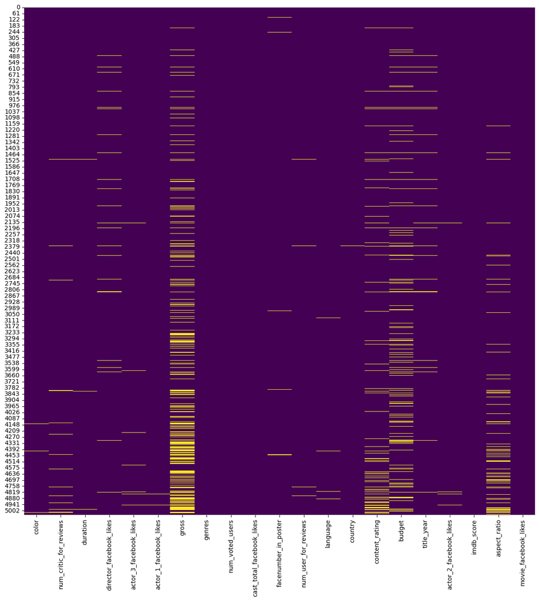

```python
fig, ax = plt.subplots(figsize=(15, 15))
sns.heatmap(dataset.isnull(), cbar=False, cmap="viridis")
```

### Imputación de datos

- Técnica de imputación con Moda: Valores más frecuentes para las columnas `color`, `facenumber_in_poster`, `language`, `aspect_ratio`

```python
features = ["color", "facenumber_in_poster", "language", "aspect_ratio"]

def impute_value_by_mode(variables):
    for var in variables:
        var_mode = dataset[var].mode()[0]
        print(f"{var}: {var_mode}")
        dataset[var] = dataset[var].fillna(var_mode)
        print(f"Validación de nulos para {var}: {dataset[var].isnull().sum()}")

impute_value_by_mode(features)
```

```
color: Color
Validación de nulos para color: 0
facenumber_in_poster: 0.0
Validación de nulos para facenumber_in_poster: 0
language: English
Validación de nulos para language: 0
aspect_ratio: 2.35
Validación de nulos para aspect_ratio: 0
```

```python
# features = ["director_name", "actor_1_name", "actor_2_name", "actor_3_name", "plot_keywords", "content_rating"]
features = ["content_rating"]

def impute_value_by_category(variables):
    for var in variables:
        category = "Unknown"
        dataset[var] = dataset[var].fillna(category)
        print(f"Validación de nulos para {var}: {dataset[var].isnull().sum()}")

impute_value_by_category(features)
```

```
Validación de nulos para content_rating: 0
```

- Técnica de imputación con Media: Media de valores para las columnas `num_critic_for_reviews`, `num_user_for_reviews`

```python
features = ["num_critic_for_reviews", "num_user_for_reviews"]

def impute_value_by_mean(variables):
    for var in variables:
        var_mean = dataset[var].mean()
        print(f"{var}: {var_mean}")
        dataset[var] = dataset[var].fillna(var_mean)
        print(f"Validación de nulos para {var}: {dataset[var].isnull().sum()}")

impute_value_by_mean(features)
```

```
num_critic_for_reviews: 140.1942719807731
Validación de nulos para num_critic_for_reviews: 0
num_user_for_reviews: 272.77080844285143
Validación de nulos para num_user_for_reviews: 0
```

- Técnica de imputación con Mediana: Mediana de valores para las columnas `duration`, `title_year`

```python
features = ["duration", "title_year"]

def impute_value_by_median(variables):
    for var in variables:
        var_median = dataset[var].median()
        print(f"{var}: {var_median}")
        dataset[var] = dataset[var].fillna(var_median)
        print(f"Validación de nulos para {var}: {dataset[var].isnull().sum()}")

impute_value_by_median(features)
```

```
duration: 103.0
Validación de nulos para duration: 0
title_year: 2005.0
Validación de nulos para title_year: 0
```

- Técnica de imputación con Ceros: Imputación con 0 para las columnas `director_facebook_likes`, `actor_1_facebook_likes`, `actor_2_facebook_likes`, `actor_3_facebook_likes`

```python
features = ["director_facebook_likes", "actor_1_facebook_likes", "actor_2_facebook_likes", "actor_3_facebook_likes"]

def impute_value_with_zeros(variables):
    for var in variables:
        dataset[var] = dataset[var].fillna(0)
        print(f"Validación de nulos para {var}: {dataset[var].isnull().sum()}")

impute_value_with_zeros(features)
```

```
Validación de nulos para director_facebook_likes: 0
Validación de nulos para actor_1_facebook_likes: 0
Validación de nulos para actor_2_facebook_likes: 0
Validación de nulos para actor_3_facebook_likes: 0
```

- Técnica de imputación por Interpolación: Interpolación de las columnas `gross`, `budget`.

```python
features = ["gross", "budget"]

def impute_value_by_interpolate(variables):
    for var in variables:
        dataset[var] = dataset[var].interpolate(method="linear")
        print(f"Validación de nulos para {var}: {dataset[var].isnull().sum()}")

impute_value_by_interpolate(features)
```

```
Validación de nulos para gross: 0
Validación de nulos para budget: 0
```

- Técnica de imputación condicional: Condicional para `country` basado en el idioma.

```python
country_by_language = {
    'Aboriginal': "Australia",
    'Arabic': random.choice(["Egypt", "Libya", "United Arab Emirates"]),
    'Aramaic': random.choice(["Siria", "Irak"]),
    'Bosnian': "Bosnia",
    'Cantonese': random.choice(["Hong Kong", "China"]),
    'Chinese': "China",
    'Czech': "Czech Republic",
    'Danish': "Denmark",
    'Dari': "Afghanistan",
    'Dutch': random.choice(["Netherlands", "Belgium", "Aruba"]),
    'Dzongkha': "Butan",
    'English': random.choice(['USA', 'UK', 'New Zealand', 'Canada', 'Australia', 'Ireland', 'South Africa', 'Bahamas', 'Nigeria', 'Philippines']),
    'Filipino': "Philippines",
    'French': random.choice(["France", "Belgium", "Canada", "Switzerland", "Cameroon"]),
    'German': random.choice(["Germany", "Austria", "Switzerland", "West Germany"]),
    'Greek': "Greece",
    'Hebrew': "Israel",
    'Hindi': "India",
    'Hungarian': "Hungary",
    'Icelandic': "Iceland",
    'Indonesian': "Indonesia",
    'Italian': random.choice(["Italy", "Switzerland"]),
    'Japanese': "Japan",
    'Kannada': "India",
    'Kazakh': "Kazakhstan",
    'Korean': "South Korea",
    'Mandarin': random.choice(["China", "Taiwan"]),
    'Maya': "Mexico",
    'Mongolian': "Mongolia",
    'Norwegian': "Norway",
    'Panjabi': random.choice(["Pakistan", "India"]),
    'Persian': random.choice(["Iran", "Afghanistan"]),
    'Polish': "Poland",
    'Portuguese': random.choice(["Brazil", "Portugal"]),
    'Romanian': "Romania",
    'Russian': random.choice(["Russia", "Soviet Union", "Kyrgyzstan"]),
    'Slovenian': "Slovenia",
    'Spanish': random.choice(["Mexico", "Spain", "Argentina", "Colombia", "Chile", "Panama", "Peru", "Dominican Republic"]),
    'Swahili': "Kenya",
    'Swedish': random.choice(["Sweden", "Finland"]),
    'Tamil': random.choice(["India", "Sri Lanka"]),
    'Telugu': "India",
    'Thai': "Thailand",
    'Urdu': random.choice(["Pakistan", "India"]),
    'Vietnamese': "Vietnam",
    'Zulu': "South Africa",
}
```

```python
def impute_country(row):
    if pd.isnull(row['country']):
        return country_by_language.get(row["language"], row['country'])
    return row['country']

dataset['country'] = dataset.apply(impute_country, axis=1) # type: ignore
print(f"Validación de nulos para country: {dataset['country'].isnull().sum()}")
```

```
Validación de nulos para country: 0
```

### Validación de datos nulos post-imputación

Revisión de conteo de nulos

```python
dataset.isnull().sum()
```

```
color                        0
num_critic_for_reviews       0
duration                     0
director_facebook_likes      0
actor_3_facebook_likes       0
actor_1_facebook_likes       0
gross                        0
genres                       0
num_voted_users              0
cast_total_facebook_likes    0
facenumber_in_poster         0
num_user_for_reviews         0
language                     0
country                      0
content_rating               0
budget                       0
title_year                   0
actor_2_facebook_likes       0
imdb_score                   0
aspect_ratio                 0
movie_facebook_likes         0
dtype: int64
```

Revisión de mapa de calor para nulos

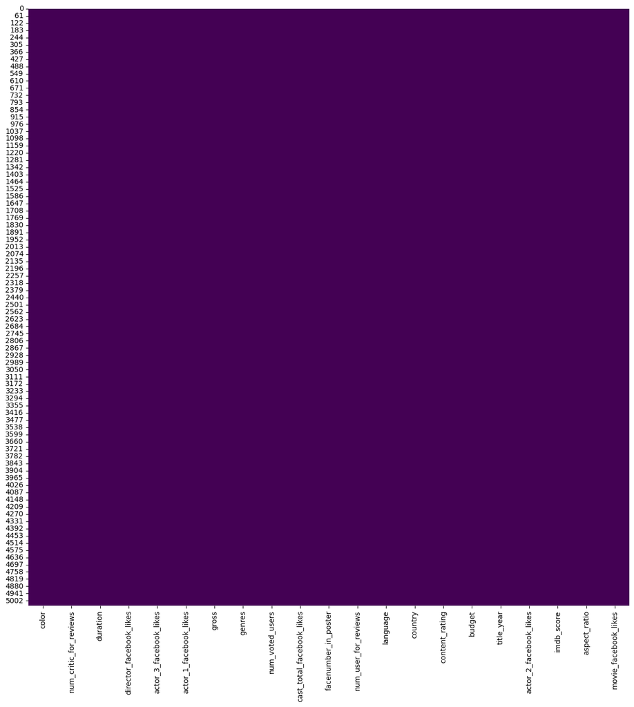

```python
fig, ax = plt.subplots(figsize=(15, 15))
sns.heatmap(dataset.isnull(), cbar=False, cmap="viridis")
```

## Análisis de Exploración de Data (EDA)

```python
is_interactive = True
```

### Boxplot Crudo

Mediante un diagrama de boxplot puedo observar cómo se distribuyen o concentran los valores en el dataset, los valores que se encuentran fuera de los bigotes indican películas con puntajes inusualmente altos o bajos, a los cuales conocemos como **outliers**. Otra función de este diagrama, es poder determinar simetría o sesgo al observar si la caja está centrada o inclinada.

Adicionalmente, puedo determinar si es necesario filtrar elementos por poca relevancia dentro del dataset.

```python
if is_interactive:
    EDAVisualizerInteractive.plot_boxplot( "Comparación de IMDb Score por País", dataset, "country", "imdb_score", "País", "IMDb Score")
else:
    EDAVisualizerStatic.plot_boxplot( "Comparación de IMDb Score por País", dataset, "country", "imdb_score", "País", "IMDb Score")
```

```
Boxplot guardado en assets\Comparación_de_IMDb_Score_por_País.html
```

### Histogramas

```python
country_counts = dataset["country"].value_counts()
q1 = country_counts.quantile(0.25)
filtered_countries = country_counts.loc[lambda s: s > q1].index.tolist()

if is_interactive:
    EDAVisualizerInteractive.plot_histogram_by_category(
        title=f"Distribución de IMDb Score en {filtered_countries[0]}" if filtered_countries else "Distribución de IMDb Score",
        subtitle="Distribución de IMDb Score en",
        data=dataset,
        category_col="country",
        value_col=target,
        categories=filtered_countries,
        nbins=20,
        x_label="IMDb Score",
        y_label="Frecuencia",
        save_html=True,
        save_folder="assets",
        height=500,
        width=900
    )
else:
    for country in filtered_countries:
        EDAVisualizerStatic.plot_histogram(
            title=f"Histograma de IMDb Score para {country}",
            data=dataset[dataset["country"] == country],
            column=target,
            x_label="IMDb Score",
            y_label="Frecuencia",
            bins=20,
            x_range=(0, 10)
        )
```

```
Histograma guardado en assets\Distribución_de_IMDb_Score_en_USA.html
```

## Filtrado del dataset

```python
dataset_filtered = dataset[dataset["country"].isin(filtered_countries)]
```

### Boxplot filtrado

Comparar los países mediante un diagrama boxplot, sin tener en cuenta a los países con pocos registros

```python
if is_interactive:
    EDAVisualizerInteractive.plot_boxplot(
        title = "Comparación filtrada de IMDb Score por País",
        data = dataset_filtered,
        x="country", y="imdb_score", x_label="País", y_label="IMDb Score"
    )
else:
    EDAVisualizerStatic.plot_boxplot(
        title = "Comparación filtrada de IMDb Score por País",
        data = dataset_filtered,
        x="country", y="imdb_score", x_label="País", y_label="IMDb Score"
    )
```

```
Boxplot guardado en assets\Comparación_filtrada_de_IMDb_Score_por_País.html
```

### Visualización de features categóricos

```python
if is_interactive:
    EDAVisualizerInteractive.plot_categorical_counts_dropdown(
        title="Frecuencia de categorías",
        data=dataset_filtered,
        categorical_cols=categorical_features,
        top_n=8,            # aplica Top 8 cuando hay muchas categorías
        template="plotly_white",
        height=500,
        width=900,
        save_html=True,     # guarda en assets/Frecuencia_de_categorías.html
        save_folder="assets",
        show=True
    )
else:
    EDAVisualizerStatic.plot_categorical_counts_grid(
        data=dataset_filtered,
        categorical_cols=categorical_features,
        n_cols=2,
        top_n=8,
        rotate_xticks=45,   # como en tu código original
        show=True
    )
```

```
Gráfico guardado en assets\Frecuencia_de_categorías.html
```

### Visualización de features numéricos

```python
if is_interactive:
    EDAVisualizerInteractive.plot_numerical_hists_dropdown(
        title="Distribuciones numéricas",
        data=dataset_filtered,
        numerical_cols=numerical_features,
        nbins=30,
        template="plotly_white",
        height=500,
        width=900,
        save_html=True,      # guarda en assets/Distribuciones_numéricas.html
        save_folder="assets",
        show=True
    )
else:
    n = 2
    plt.figure(figsize=[15, 3 * math.ceil(len(numerical_features) / n)])

    for i, col in enumerate(numerical_features):
        plt.subplot(math.ceil(len(numerical_features) / n), n, i + 1)
        sns.histplot(data=dataset_filtered, x=col, bins=30, kde=True, color='steelblue')
        plt.title(col)
        plt.xlabel(col)
        plt.ylabel("Frecuencia")

    plt.tight_layout(pad=2.0)
    plt.subplots_adjust(hspace=0.6, wspace=0.4)
    plt.show()
```

```
Gráfico guardado en assets\Distribuciones_numéricas.html
```

### Matriz de dispersión

Entender la relación entre todas las características

```python
if is_interactive:
    EDAVisualizerInteractive.plot_pairplot(
        dataset = dataset_filtered,
        title = 'Matriz de dispersión interactiva',
        height = 2500,
        width = 2500,
    )
else:
    EDAVisualizerStatic.plot_pairplot(
        dataset = dataset_filtered,
        title = 'Pairplots for all the Feature'
    )
```

```
Gráfico guardado en assets\Matriz_de_dispersión_interactiva.html
```

## Eliminar outliers

Se eliminan las filas donde alguna variable tiene un z-score (puntaje estándar que indica cuantas desviaciones estándar se encuentra un valor con respecto a la media de su distribución) mayor a 3.

Si el valor de z-score está en 0, el valor está exactamente en la media. Si es +1, el valor está 1 desviación estándar por encima de la media. Si el valor es -2, el valor está 2 desviaciones estándar por debajo de la media. Si el valor es mayor a +3 o menor a -3, el valor se considera un outlier.

```python
z_scores = np.abs(zscore(dataset_filtered.select_dtypes(include='number'))) # type: ignore
dataset_no_outliers = dataset_filtered[(z_scores < 3).all(axis=1)]
```

Se calcula el IQR solo sobre las columnas numéricas y se filtran filas sin outliers.

```python
numeric_cols = dataset_filtered.select_dtypes(include='number')

Q1 = numeric_cols.quantile(0.25)
Q3 = numeric_cols.quantile(0.75)
IQR = Q3 - Q1

dataset_no_outliers = dataset_filtered[~((numeric_cols < (Q1 - 1.5 * IQR)) | (numeric_cols > (Q3 + 1.5 * IQR))).any(axis=1)]
```

```python
if is_interactive:
    EDAVisualizerInteractive.plot_boxplot(
        title = "Comparación sin outliers de IMDb Score por País",
        data = dataset_no_outliers,
        x="country", y="imdb_score", x_label="País", y_label="IMDb Score"
    )
else:
    EDAVisualizerStatic.plot_boxplot(
        title = "Comparación sin outliers de IMDb Score por País",
        data = dataset_no_outliers,
        x="country", y="imdb_score", x_label="País", y_label="IMDb Score"
    )
```

```
Boxplot guardado en assets\Comparación_sin_outliers_de_IMDb_Score_por_País.html
```

## One hot encoding

```python
dataset_no_outliers = dataset_no_outliers.copy()

dataset_no_outliers['genres'] = dataset_no_outliers['genres'].fillna('')

dataset_no_outliers['genres_list'] = dataset_no_outliers['genres'].apply(lambda x: x.split('|'))

mlb = MultiLabelBinarizer()
genres_encoded = pd.DataFrame(mlb.fit_transform(dataset_no_outliers['genres_list']), columns=mlb.classes_, index=dataset_no_outliers.index) # type: ignore

dataset_no_outliers = pd.concat([dataset_no_outliers, genres_encoded], axis=1)
```

```python
dataset_no_outliers = dataset_no_outliers.drop('genres', axis=1)
dataset_no_outliers = dataset_no_outliers.drop('genres_list', axis=1)
categorical_features.remove("genres")
```

```python
dataset_no_outliers.head()
```

|  | color | num_critic_for_reviews | duration | director_facebook_likes | actor_3_facebook_likes | actor_1_facebook_likes | gross | num_voted_users | cast_total_facebook_likes | facenumber_in_poster | ... | Music | Musical | Mystery | News | Romance | Sci-Fi | Sport | Thriller | War | Western |
| --- | --- | --- | --- | --- | --- | --- | --- | --- | --- | --- | --- | --- | --- | --- | --- | --- | --- | --- | --- | --- | --- |
| 177 | Color | 21.0 | 60.0 | 0.0 | 184.0 | 982.0 | 93655348.5 | 16769 | 1687 | 2.0 | ... | 0 | 0 | 1 | 0 | 0 | 0 | 0 | 1 | 0 | 0 |
| 215 | Color | 85.0 | 102.0 | 323.0 | 241.0 | 845.0 | 32694788.0 | 101411 | 1815 | 1.0 | ... | 0 | 0 | 0 | 0 | 0 | 0 | 0 | 0 | 0 | 0 |
| 242 | Color | 33.0 | 116.0 | 0.0 | 141.0 | 936.0 | 114038688.0 | 20567 | 1609 | 1.0 | ... | 0 | 0 | 0 | 0 | 0 | 0 | 0 | 0 | 0 | 0 |
| 306 | Color | 174.0 | 121.0 | 0.0 | 595.0 | 1000.0 | 66862068.0 | 89509 | 3903 | 0.0 | ... | 0 | 0 | 1 | 0 | 0 | 0 | 0 | 0 | 0 | 0 |
| 324 | Color | 97.0 | 110.0 | 342.0 | 393.0 | 623.0 | 10200000.0 | 18697 | 1722 | 0.0 | ... | 0 | 0 | 1 | 0 | 0 | 0 | 0 | 1 | 0 | 0 |

5 rows × 42 columns

```python
dataset_no_outliers.info()
```

```
<class 'pandas.core.frame.DataFrame'>
Index: 2349 entries, 177 to 5042
Data columns (total 42 columns):
 #   Column                     Non-Null Count  Dtype
---  ------                     --------------  -----
 0   color                      2349 non-null   object
 1   num_critic_for_reviews     2349 non-null   float64
 2   duration                   2349 non-null   float64
 3   director_facebook_likes    2349 non-null   float64
 4   actor_3_facebook_likes     2349 non-null   float64
 5   actor_1_facebook_likes     2349 non-null   float64
 6   gross                      2349 non-null   float64
 7   num_voted_users            2349 non-null   int64
 8   cast_total_facebook_likes  2349 non-null   int64
 9   facenumber_in_poster       2349 non-null   float64
```

[output cut: 34 more lines]

### Variables dummies

```python
# language_dummies = pd.get_dummies(dataset_no_outliers['language'], prefix='lang')
# dataset_no_outliers = dataset_no_outliers.drop('language', axis=1)
# dataset_no_outliers = pd.concat([dataset_no_outliers, language_dummies], axis=1)
```

```python
dummies = pd.get_dummies(dataset_no_outliers[categorical_features], drop_first=True)
dataset_no_outliers = pd.concat([dataset_no_outliers.drop(columns=categorical_features), dummies], axis=1)
```

```python
dataset_no_outliers.head()
```

|  | num_critic_for_reviews | duration | director_facebook_likes | actor_3_facebook_likes | actor_1_facebook_likes | gross | num_voted_users | cast_total_facebook_likes | num_user_for_reviews | budget | ... | content_rating_PG | content_rating_PG-13 | content_rating_R | content_rating_TV-14 | content_rating_TV-G | content_rating_TV-MA | content_rating_TV-PG | content_rating_Unknown | content_rating_Unrated | content_rating_X |
| --- | --- | --- | --- | --- | --- | --- | --- | --- | --- | --- | --- | --- | --- | --- | --- | --- | --- | --- | --- | --- | --- |
| 177 | 21.0 | 60.0 | 0.0 | 184.0 | 982.0 | 93655348.5 | 16769 | 1687 | 74.0 | 1500000.0 | ... | False | False | False | True | False | False | False | False | False | False |
| 215 | 85.0 | 102.0 | 323.0 | 241.0 | 845.0 | 32694788.0 | 101411 | 1815 | 546.0 | 85000000.0 | ... | False | False | True | False | False | False | False | False | False | False |
| 242 | 33.0 | 116.0 | 0.0 | 141.0 | 936.0 | 114038688.0 | 20567 | 1609 | 36.0 | 78000000.0 | ... | False | False | False | False | False | False | False | True | False | False |
| 306 | 174.0 | 121.0 | 0.0 | 595.0 | 1000.0 | 66862068.0 | 89509 | 3903 | 524.0 | 83000000.0 | ... | False | False | True | False | False | False | False | False | False | False |
| 324 | 97.0 | 110.0 | 342.0 | 393.0 | 623.0 | 10200000.0 | 18697 | 1722 | 263.0 | 10000000.0 | ... | True | False | False | False | False | False | False | False | False | False |

5 rows × 118 columns

```python
dataset_no_outliers.info()
```

```
<class 'pandas.core.frame.DataFrame'>
Index: 2349 entries, 177 to 5042
Columns: 118 entries, num_critic_for_reviews to content_rating_X
dtypes: bool(80), float64(13), int64(25)
memory usage: 899.2 KB
```

### Inferencia de tipos de variables post one hot encoding

```python
target = 'imdb_score'
features = [i for i in dataset_no_outliers.columns if i not in [target]]
number_unique_rows = dataset_no_outliers[features].nunique()
```

```python
numerical_features = [];
categorical_features = [];

for col in features:
    if dataset_no_outliers[col].dtype == 'object' or number_unique_rows[col] <= 45:
        categorical_features.append(col)
    else:
        numerical_features.append(col)

print('\n\033[1mInferencia:\033[0m El dataset tiene {} features numéricas y {} features categóricas.'.format(len(numerical_features),len(categorical_features)))
```

```
Inferencia: El dataset tiene 12 features numéricas y 105 features categóricas.
```

### Matriz de correlación

```python
correlation_matrix = dataset_no_outliers.select_dtypes(include=['int64', 'float64']).corr().round(2)

if is_interactive:
    EDAVisualizerInteractive.plot_heatmap(correlation_matrix, "Mapa de Calor Interactivo de Correlaciones", 1200, 1200, 7)
else:
    EDAVisualizerStatic.plot_heatmap(correlation_matrix, figsize=(50,25))
```

```
Gráfico guardado en assets\Mapa_de_Calor_Interactivo_de_Correlaciones.html
```

Transformación de matriz de correlación en formato de pares

```python
correlation_pairs = correlation_matrix.unstack()
correlation_pairs
```

```
num_critic_for_reviews  num_critic_for_reviews     1.00
                        duration                   0.16
                        director_facebook_likes    0.21
                        actor_3_facebook_likes     0.13
                        actor_1_facebook_likes     0.20
                                                   ...
aspect_ratio            Thriller                   0.14
                        War                        0.08
                        Western                    0.07
                        facenumber_in_poster       0.02
                        aspect_ratio               1.00
Length: 1444, dtype: float64
```

Filtrado de variables con una correlación mayor al 0.6

```python
threshold = 0.6
```

```python
sorted_pairs = correlation_pairs.sort_values(ascending=False) # type: ignore

high_correlated_pairs = sorted_pairs[((sorted_pairs > threshold) | (sorted_pairs < -threshold)) & (sorted_pairs != 1)]
high_correlated_pairs
```

```
actor_1_facebook_likes     cast_total_facebook_likes    0.98
cast_total_facebook_likes  actor_1_facebook_likes       0.98
actor_2_facebook_likes     actor_3_facebook_likes       0.85
actor_3_facebook_likes     actor_2_facebook_likes       0.85
num_voted_users            num_user_for_reviews         0.74
num_user_for_reviews       num_voted_users              0.74
num_critic_for_reviews     num_user_for_reviews         0.64
num_user_for_reviews       num_critic_for_reviews       0.64
dtype: float64
```

```python
vars_corr = list(set([i[0] for i in high_correlated_pairs.index] + [i[1] for i in high_correlated_pairs.index]))

filtered_corr = correlation_matrix.loc[vars_corr, vars_corr]

if is_interactive:
    EDAVisualizerInteractive.plot_heatmap(filtered_corr, "Mapa de Calor de Pares Altamente Correlacionados", 900, 900, 12)
else:
    EDAVisualizerStatic.plot_heatmap(filtered_corr, figsize=(20,10))
```

```
Gráfico guardado en assets\Mapa_de_Calor_de_Pares_Altamente_Correlacionados.html
```

Con los resultados anteriores, se puede observar que existen variables altamente correlacionadas que se pueden interpretar de la siguiente manera:

- `cast_total_facebook_likes` y `actor_1_facebook_likes` → 0.98: El actor principal suele tener una gran influencia en el total de likes del elenco. Podrías considerar eliminar una de estas variables en modelos lineales para evitar colinealidad.
- `actor_2_facebook_likes` y `actor_3_facebook_likes` → 0.85: Los actores secundarios tienden a tener niveles de popularidad similares, posiblemente por compartir tipo de rol o nivel de exposición.
- `num_voted_users` y `num_user_for_reviews` → 0.74: A mayor cantidad de votos, mayor cantidad de reseñas. Esto puede reflejar popularidad.
- `num_critic_for_reviews` y `num_user_for_reviews` → 0.64: - Las películas con más reseñas de usuarios también tienden a recibir más atención de críticos. Refleja visibilidad mediática.

## Reducción de dimensionalidad

Para la reducción de dimensionalidad, usaré PCA (Análisis de Componentes Principales). El PCA servirá para reducir simplificar el dataset con muchas variables numéricas. Además, elimina redundancia si varias columnas están correlacionadas al combinarlo en componentes más informativos.

```python
x_num = dataset_no_outliers.drop(columns=['imdb_score']).select_dtypes(include=['int64', 'float64']).dropna()
x_scaled = StandardScaler().fit_transform(x_num)
```

### Dimensionalidad en 2D

```python
pca = PCA(n_components=2)
x_pca = pca.fit_transform(x_scaled)
```

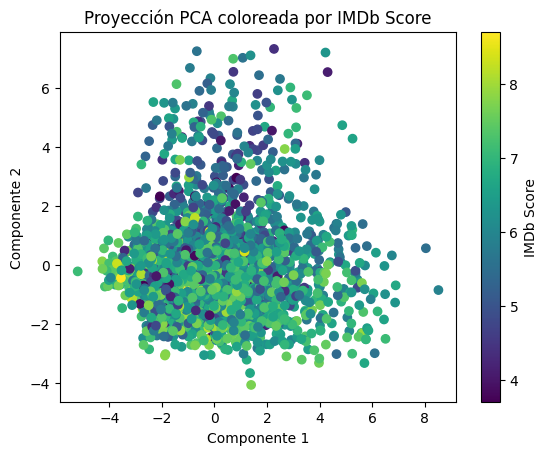

```python
plt.scatter(x_pca[:, 0], x_pca[:, 1], c=dataset_no_outliers[target], cmap='viridis')
plt.xlabel('Componente 1')
plt.ylabel('Componente 2')
plt.title('Proyección PCA coloreada por IMDb Score')
plt.colorbar(label='IMDb Score')
plt.show()
```

```python
loadings = pd.DataFrame(pca.components_.T,
                        columns=['PC1', 'PC2'],
                        index=x_num.columns)

loadings.head(10)
```

|  | PC1 | PC2 |
| --- | --- | --- |
| num_critic_for_reviews | 0.279405 | -0.164931 |
| duration | 0.141880 | -0.235369 |
| director_facebook_likes | 0.128136 | -0.083867 |
| actor_3_facebook_likes | 0.286269 | 0.114801 |
| actor_1_facebook_likes | 0.288075 | -0.032980 |
| gross | 0.278304 | 0.163043 |
| num_voted_users | 0.364319 | -0.044537 |
| cast_total_facebook_likes | 0.320105 | -0.004969 |
| num_user_for_reviews | 0.341804 | -0.124066 |
| budget | 0.313881 | 0.131411 |

```python
loadings['PC1'].sort_values(ascending=False).head(10)
```

```
num_voted_users              0.364319
num_user_for_reviews         0.341804
cast_total_facebook_likes    0.320105
budget                       0.313881
actor_2_facebook_likes       0.304629
actor_1_facebook_likes       0.288075
actor_3_facebook_likes       0.286269
num_critic_for_reviews       0.279405
gross                        0.278304
Action                       0.145027
Name: PC1, dtype: float64
```

Partiendo de tales categorías, se podría decir que PC1 representa una dimensión de "exposición y recepción pública", es decir, qué tan visible, votada, comentada y económicamente exitosa es una película. Las películas con valores altos en PC1 tienden a ser más votadas, más comentadas, más exitosas comercialmente y más visibles en redes sociales.

```python
loadings['PC2'].sort_values(ascending=False).head(10)
```

```
Family                    0.402911
Animation                 0.339887
Comedy                    0.321957
Adventure                 0.289094
Fantasy                   0.264886
gross                     0.163043
Musical                   0.150288
budget                    0.131411
actor_3_facebook_likes    0.114801
actor_2_facebook_likes    0.095359
Name: PC2, dtype: float64
```

En el componente principal 2 (PC2) se encuentra la segunda dirección de máxima variación en los datos. En este caso, el componente logra capturar la dimensión temática y estilística de las películas. A diferencia del PC1, el PC2 se enfoca más en el contenido narrativo y el tipo de audiencia. En ese sentido, podria decir que PC2 representa una dimensión de "narrativa y audiencia", es decir, qué tan narrativa y popular es una película. Las películas con valores altos en PC2 tienden a estar más enfocadas a públicos amplios o familiares, haciendo uso de animación, fantasía y aventura y comedia, además, tienen una posible asociación con producciones de alto presupuesto pero un enfoque narrativo más ligero.

### Dimensionalidad en 3D

```python
pca = PCA(n_components=3)
x_pca = pca.fit_transform(x_scaled)
```

```python
dataset_pca = pd.DataFrame(x_pca, columns=['PC1', 'PC2', 'PC3'])
dataset_pca['IMDb Score'] = dataset_no_outliers['imdb_score']


if is_interactive:
    EDAVisualizerInteractive.plot_3d_projection(
        dataset=dataset_pca,
        title='Proyección PCA en 3D (Interactiva)',
        x_label="PC1",
        y_label="PC2",
        z_label="PC3",
        label="IMDb Score"
    )
else:
    EDAVisualizerStatic.plot_3d_projection(
        dataset=dataset_no_outliers,
        column='imdb_score',
        title='Proyección PCA en 3D coloreada por IMDb Score',
        x_label="Componente 1",
        y_label="Componente 2",
        z_label="Componente 3",
        cbar_label="IMDb Score",
        figsize=(10, 8)
    )
```

```
Gráfico guardado en assets\Proyección_PCA_en_3D_Interactiva.html
```

```python
loadings = pd.DataFrame(pca.components_.T,
                        columns=['PC1', 'PC2', 'PC3'],
                        index=x_num.columns)

loadings.head(10)
```

|  | PC1 | PC2 | PC3 |
| --- | --- | --- | --- |
| num_critic_for_reviews | 0.279405 | -0.164931 | 0.116179 |
| duration | 0.141880 | -0.235369 | -0.147009 |
| director_facebook_likes | 0.128136 | -0.083867 | 0.007356 |
| actor_3_facebook_likes | 0.286269 | 0.114801 | -0.201801 |
| actor_1_facebook_likes | 0.288075 | -0.032980 | -0.236891 |
| gross | 0.278304 | 0.163043 | 0.072336 |
| num_voted_users | 0.364319 | -0.044537 | 0.083702 |
| cast_total_facebook_likes | 0.320105 | -0.004969 | -0.256920 |
| num_user_for_reviews | 0.341804 | -0.124066 | 0.134412 |
| budget | 0.313881 | 0.131411 | 0.069345 |

```python
loadings['PC1'].sort_values(ascending=False).head(10)
```

```
num_voted_users              0.364319
num_user_for_reviews         0.341804
cast_total_facebook_likes    0.320105
budget                       0.313881
actor_2_facebook_likes       0.304629
actor_1_facebook_likes       0.288075
actor_3_facebook_likes       0.286269
num_critic_for_reviews       0.279405
gross                        0.278304
Action                       0.145027
Name: PC1, dtype: float64
```

```python
loadings['PC2'].sort_values(ascending=False).head(10)
```

```
Family                    0.402911
Animation                 0.339887
Comedy                    0.321957
Adventure                 0.289094
Fantasy                   0.264886
gross                     0.163043
Musical                   0.150288
budget                    0.131411
actor_3_facebook_likes    0.114801
actor_2_facebook_likes    0.095359
Name: PC2, dtype: float64
```

```python
loadings['PC3'].sort_values(ascending=False).head(10)
```

```
Horror                    0.321810
Thriller                  0.308382
Sci-Fi                    0.240482
Mystery                   0.231936
Action                    0.212305
Adventure                 0.153874
Fantasy                   0.152227
num_user_for_reviews      0.134412
num_critic_for_reviews    0.116179
Animation                 0.103772
Name: PC3, dtype: float64
```

Con relación al componente 3 (PC3), captura aspectos más sutiles o específicos, tal como combinaciones de géneros o temas narrativos. En este caso, se asocia con una dimensión de intensidad narrativa y oscuridad temática, además de que sirve como contraste con el PC2, ya que facilita un análisis entre producciones de alto impacto emocional y aquellas que buscan ser más ligeras y familiares.

La segmentación temática la podemos tomar apoyados con el PC2 y PC3, ya que clasifican películas por tono narrativo. Al comparar el PC1 con el puntaje IMDb, se revela si la popularidad se asocia con calidad.

## Regresión lineal múltiple

### Regresión lineal con todas las variables y sin PCA

```python
X = dataset_no_outliers.drop(columns=['imdb_score'])
y = dataset_no_outliers['imdb_score']
```

```python
linearRegressionWithoutPCA = CustomLinearRegression(X, y, "Linear_regression_without_PCA")
linearRegressionWithoutPCA.run()
```

```
--> Iniciando la division del dataset
	Tamaño del dataset: 2349
	Tamaño del dataset de entrenamiento: 1879
	Tamaño del dataset de prueba: 470
----------------------------------------
--> Iniciando el entrenamiento del modelo
----------------------------------------
--> Iniciando la predicción del modelo
----------------------------------------
--> Iniciando la evaluación del modelo
	Error absoluto medio (MAE): 0.55
	Error cuadrático medio (MSE): 0.49
	Coeficiente de determinación (R²): 0.37
----------------------------------------
--> Iniciando la creación del dataframe de coeficientes
----------------------------------------
--> Prediciendo sobre entrenamiento y prueba
----------------------------------------
--> Graficando comparación interactiva del modelo
```

```
	Gráfico guardado en assets/Linear_regression_without_PCA_plot_comparison_interactive.html
----------------------------------------
--> Graficando residuos interactivos
```

```
	Gráfico guardado en assets/Linear_regression_without_PCA_plot_residuals_interactive.html
----------------------------------------
--> Graficando importance de variables interactiva
```

```
	Gráfico guardado en assets/Linear_regression_without_PCA_plot_feature_importance_interactive.html
----------------------------------------
```

```python
linearRegressionWithoutPCA.summary()
```

```
RESUMEN DEL MODELO
----------------------------------------
--> Métricas de desempeño:
```

|  | Total Features | MAE | MSE | R2 |
| --- | --- | --- | --- | --- |
| 0 | 117 | 0.554729 | 0.489994 | 0.370654 |

```
--> Principales coeficientes:
```

|  | Variable | Coeficiente |
| --- | --- | --- |
| 110 | content_rating_TV-14 | 1.995736 |
| 112 | content_rating_TV-MA | 1.905801 |
| 84 | country_Iran | 1.775891 |
| 111 | content_rating_TV-G | 1.252832 |
| 50 | language_Hebrew | 1.214865 |
| 19 | Documentary | 1.097230 |
| 54 | language_Japanese | 0.973191 |
| 60 | language_Norwegian | 0.960085 |
| 113 | content_rating_TV-PG | 0.909462 |
| 44 | language_Dutch | 0.817249 |

### Regresión lineal con PCA

```python
X = x_pca
y = dataset_no_outliers['imdb_score']
```

```python
linearRegressionWithPCA = CustomLinearRegression(X, y, "Linear_regression_with_PCA")
linearRegressionWithPCA.run()
```

```
--> Iniciando la division del dataset
	Tamaño del dataset: 2349
	Tamaño del dataset de entrenamiento: 1879
	Tamaño del dataset de prueba: 470
----------------------------------------
--> Iniciando el entrenamiento del modelo
----------------------------------------
--> Iniciando la predicción del modelo
----------------------------------------
--> Iniciando la evaluación del modelo
	Error absoluto medio (MAE): 0.69
	Error cuadrático medio (MSE): 0.74
	Coeficiente de determinación (R²): 0.05
----------------------------------------
--> Iniciando la creación del dataframe de coeficientes
----------------------------------------
--> Prediciendo sobre entrenamiento y prueba
----------------------------------------
--> Graficando comparación interactiva del modelo
```

```
	Gráfico guardado en assets/Linear_regression_with_PCA_plot_comparison_interactive.html
----------------------------------------
--> Graficando residuos interactivos
```

```
	Gráfico guardado en assets/Linear_regression_with_PCA_plot_residuals_interactive.html
----------------------------------------
--> Graficando importance de variables interactiva
```

```
	Gráfico guardado en assets/Linear_regression_with_PCA_plot_feature_importance_interactive.html
----------------------------------------
```

```python
linearRegressionWithPCA.summary()
```

```
RESUMEN DEL MODELO
----------------------------------------
--> Métricas de desempeño:
```

|  | Total Features | MAE | MSE | R2 |
| --- | --- | --- | --- | --- |
| 0 | 3 | 0.694786 | 0.741951 | 0.047041 |

```
--> Principales coeficientes:
```

|  | Variable | Coeficiente |
| --- | --- | --- |
| 0 | PC1 | -0.023093 |
| 2 | PC3 | -0.105278 |
| 1 | PC2 | -0.163191 |

## Pruebas con otros modelos

### Regresión Random Forest

```python
X = dataset_no_outliers[features]
y = dataset_no_outliers[target]

# Entrenar modelo
rf = RandomForestRegressor(n_estimators=100, random_state=42)
rf.fit(X, y)

# Predecir sobre el mismo conjunto (evaluación interna)
y_pred_rf = rf.predict(X)

# Métricas de evaluación
mse = mean_squared_error(y, y_pred_rf)
r2 = r2_score(y, y_pred_rf)

print(f"Error cuadrático medio (MSE): {mse:.2f}")
print(f"Coeficiente de determinación (R²): {r2:.2f}")
```

```
Error cuadrático medio (MSE): 0.07
Coeficiente de determinación (R²): 0.92
```

### Regresión Gradient Boosting

```python
X = dataset_no_outliers[features]
y = dataset_no_outliers[target]

# Entrenar modelo
gb = GradientBoostingRegressor(n_estimators=100, learning_rate=0.1, random_state=42)
gb.fit(X, y)

# Predecir sobre el mismo conjunto (evaluación interna)
y_pred_gb = gb.predict(X)

# Métricas de evaluación
mse_gb = mean_squared_error(y, y_pred_gb)
r2_gb = r2_score(y, y_pred_gb)

print(f"Error cuadrático medio (MSE): {mse_gb:.2f}")
print(f"Coeficiente de determinación (R²): {r2_gb:.2f}")
```

```
Error cuadrático medio (MSE): 0.31
Coeficiente de determinación (R²): 0.65
```

### Support Vector Machine

```python
X = dataset_no_outliers[features]
y = dataset_no_outliers[target]

# Entrenar modelo SVR
svr = SVR(kernel='rbf', C=1.0, epsilon=0.2)
svr.fit(X, y)

# Predecir sobre el mismo conjunto (evaluación interna)
y_pred_svr = svr.predict(X)

# Métricas de evaluación
mse_svr = mean_squared_error(y, y_pred_svr)
r2_svr = r2_score(y, y_pred_svr)

print(f"Error cuadrático medio (MSE): {mse_svr:.2f}")
print(f"Coeficiente de determinación (R²): {r2_svr:.2f}")
```

```
Error cuadrático medio (MSE): 0.84
Coeficiente de determinación (R²): 0.04
```

### K Nearest Neighbors

```python
X = dataset_no_outliers[features]
y = dataset_no_outliers[target]

# Entrenar modelo KNN
knn = KNeighborsRegressor(n_neighbors=5)
knn.fit(X, y)

# Predecir sobre el mismo conjunto (evaluación interna)
y_pred_knn = knn.predict(X)

# Métricas de evaluación
mse_knn = mean_squared_error(y, y_pred_knn)
r2_knn = r2_score(y, y_pred_knn)

print(f"Error cuadrático medio (MSE): {mse_knn:.2f}")
print(f"Coeficiente de determinación (R²): {r2_knn:.2f}")
```

```
Error cuadrático medio (MSE): 0.66
Coeficiente de determinación (R²): 0.25
```

### Ridge

```python
X = dataset_no_outliers[features]
y = dataset_no_outliers[target]

# Entrenar modelo Ridge
ridge = Ridge(alpha=1.0)
ridge.fit(X, y)

# Predecir sobre el mismo conjunto (evaluación interna)
y_pred_ridge = ridge.predict(X)

# Métricas de evaluación
mse_ridge = mean_squared_error(y, y_pred_ridge)
r2_ridge = r2_score(y, y_pred_ridge)

print(f"Error cuadrático medio (MSE Ridge): {mse_ridge:.2f}")
print(f"Coeficiente de determinación (R² Ridge): {r2_ridge:.2f}")
```

```
Error cuadrático medio (MSE Ridge): 0.46
Coeficiente de determinación (R² Ridge): 0.47
```

## Prueba con alta correlación

```python
X = dataset_no_outliers[features]
y = dataset_no_outliers[target]
```

```python
models = {
    'Linear': LinearRegression(),
    'Random Forest': RandomForestRegressor(n_estimators=100, random_state=42),
    'Gradient Boosting': GradientBoostingRegressor(n_estimators=100, learning_rate=0.1, random_state=42),
    'SVR': SVR(kernel='rbf', C=1.0, epsilon=0.2),
    'K Neighbors': KNeighborsRegressor(n_neighbors=5),
    'Ridge': Ridge(alpha=1.0)
}

results = {
    'Modelo': [],
    'R²': [],
    'MSE': []
}

for name, model in models.items():
    r2_scores = cross_val_score(model, X, y, cv=5, scoring='r2').mean()
    mse_scores = -cross_val_score(model, X, y, cv=5, scoring='neg_mean_squared_error').mean()
    print(f"{name} → R²: {r2_scores:.3f}, MSE: {mse_scores:.3f}")

    results['Modelo'].append(name)
    results['R²'].append(round(r2_scores.mean(), 3))
    results['MSE'].append(round(-mse_scores.mean(), 2))


fig = go.Figure()

# R²
fig.add_trace(go.Bar(
    x=results['Modelo'],
    y=results['R²'],
    name='R²',
    marker_color='mediumseagreen',
    text=results['R²'],
    textposition='auto'
))

# MSE
fig.add_trace(go.Bar(
    x=results['Modelo'],
    y=results['MSE'],
    name='MSE',
    marker_color='indianred',
    text=results['MSE'],
    textposition='auto'
))

# Configuración del gráfico
fig.update_layout(
    title='Comparación de Modelos de Regresión (Validación Cruzada)',
    barmode='group',
    xaxis_title='Modelo',
    yaxis_title='Valor',
    template='plotly_white',
    width=1000,
    height=600
)

fig.show()

fig_title = "assets/Validacion_cruzada_modelos.html"
fig.write_html(fig_title)
print("Gráfica guardada en", fig_title)
```

```
Linear → R²: 0.351, MSE: 0.556
Random Forest → R²: 0.397, MSE: 0.514
Gradient Boosting → R²: 0.438, MSE: 0.481
SVR → R²: -0.024, MSE: 0.868
K Neighbors → R²: -0.167, MSE: 0.990
Ridge → R²: 0.372, MSE: 0.537
```

[output not shown]

```
Gráfica guardada en assets/Validacion_cruzada_modelos.html
```